# Tweet EDA

If there are packages you don’t have, use `install.packages("package_name")`

```r
# Packages ----
library(tidyverse)
library(lubridate)
library(tidytext)

# Plot defaults ----
theme_set(theme_bw())

# Knitr options ----
knitr::opts_chunk$set(message = FALSE, warning = FALSE)
```

## Data

List all `.csv` files using the [`fs`](https://github.com/r-lib/fs) package.

Read in all the files in a list called `tweets_list` using the [`purrr`](https://purrr.tidyverse.org/) package.

```r
tweets_list <- map(csv_files, read_csv)
```

[output not shown]

[output cut: 44 more lines]

[output not shown]

Check the data for problems that occured when parsing.

[output not shown]

Count the columns and issues that occured.

| col | expected | n |
| --- | --- | --- |
| alt_external_id | a double | 4 |
| external_author_id | a double | 4 |
| post_type | 1/0/T/F/TRUE/FALSE | 427106 |
| tco3_step1 | 1/0/T/F/TRUE/FALSE | 14101 |

Check column types of problem columns.

| tco3_step1 | post_type | external_author_id | alt_external_id |
| --- | --- | --- | --- |
| logical | character | numeric | numeric |
| logical | logical | numeric | numeric |
| logical | logical | numeric | numeric |
| logical | logical | numeric | numeric |
| character | character | numeric | numeric |
| logical | character | numeric | numeric |
| character | character | numeric | numeric |
| logical | logical | numeric | numeric |
| logical | character | numeric | numeric |
| logical | character | numeric | numeric |

[output cut: 3 more lines]

Look at problem columns.

| row | col | expected | actual | file |
| --- | --- | --- | --- | --- |
| 1100 | post_type | 1/0/T/F/TRUE/FALSE | RETWEET | 'IRAhandle_tweets_10.csv' |
| 1344 | post_type | 1/0/T/F/TRUE/FALSE | RETWEET | 'IRAhandle_tweets_10.csv' |
| 2909 | post_type | 1/0/T/F/TRUE/FALSE | QUOTE_TWEET | 'IRAhandle_tweets_10.csv' |
| 3506 | post_type | 1/0/T/F/TRUE/FALSE | RETWEET | 'IRAhandle_tweets_10.csv' |
| 4628 | post_type | 1/0/T/F/TRUE/FALSE | RETWEET | 'IRAhandle_tweets_10.csv' |
| 4636 | post_type | 1/0/T/F/TRUE/FALSE | RETWEET | 'IRAhandle_tweets_10.csv' |
| 4637 | post_type | 1/0/T/F/TRUE/FALSE | RETWEET | 'IRAhandle_tweets_10.csv' |
| 4641 | post_type | 1/0/T/F/TRUE/FALSE | RETWEET | 'IRAhandle_tweets_10.csv' |
| 4642 | post_type | 1/0/T/F/TRUE/FALSE | RETWEET | 'IRAhandle_tweets_10.csv' |
| 4646 | post_type | 1/0/T/F/TRUE/FALSE | RETWEET | 'IRAhandle_tweets_10.csv' |

[output cut: 990 more lines]

Address issues on data read.

Recheck problem columns.

| tco3_step1 | post_type | external_author_id | alt_external_id |
| --- | --- | --- | --- |
| character | character | character | character |
| character | character | character | character |
| character | character | character | character |
| character | character | character | character |
| character | character | character | character |
| character | character | character | character |
| character | character | character | character |
| character | character | character | character |
| character | character | character | character |
| character | character | character | character |

[output cut: 3 more lines]

Recheck for any new / persistent problems.

| row | col | expected | actual |
| --- | --- | --- | --- |

Combine list data into single `tibble`.

| external_author_id | author | content | region | language | publish_date | harvested_date | following | followers | updates | post_type | account_type | retweet | account_category | new_june_2018 | alt_external_id | tweet_id | article_url | tco1_step1 | tco2_step1 | tco3_step1 |
| --- | --- | --- | --- | --- | --- | --- | --- | --- | --- | --- | --- | --- | --- | --- | --- | --- | --- | --- | --- | --- |
| 906000000000000000 | 10_GOP | "We have a sitting Democrat US Senator on trial for corruption and you've barely heard a peep from the mainstream media." ~ @nedryun https://t.co/gh6g0D1oiC | Unknown | English | 10/1/2017 19:58 | 10/1/2017 19:59 | 1052 | 9636 | 253 | NA | Right | 0 | RightTroll | 0 | 905874659358453760 | 9.145804e+17 | http://twitter.com/905874659358453760/statuses/914580356430536707 | https://twitter.com/10_gop/status/914580356430536707/video/1 | NA | NA |
| 906000000000000000 | 10_GOP | Marshawn Lynch arrives to game in anti-Trump shirt. Judging by his sagging pants the shirt should say Lynch vs. belt https://t.co/mLH1i30LZZ | Unknown | English | 10/1/2017 22:43 | 10/1/2017 22:43 | 1054 | 9637 | 254 | NA | Right | 0 | RightTroll | 0 | 905874659358453760 | 9.146218e+17 | http://twitter.com/905874659358453760/statuses/914621840496189440 | https://twitter.com/damienwoody/status/914568524449959937/video/1 | NA | NA |
| 906000000000000000 | 10_GOP | Daughter of fallen Navy Sailor delivers powerful monologue on anthem protests, burns her NFL packers gear. #BoycottNFL https://t.co/qDlFBGMeag | Unknown | English | 10/1/2017 22:50 | 10/1/2017 22:51 | 1054 | 9637 | 255 | RETWEET | Right | 1 | RightTroll | 0 | 905874659358453760 | 9.146235e+17 | http://twitter.com/905874659358453760/statuses/914623490375979008 | https://twitter.com/10_gop/status/913231923715198976/video/1 | NA | NA |
| 906000000000000000 | 10_GOP | JUST IN: President Trump dedicates Presidents Cup golf tournament trophy to the people of Florida, Texas and Puerto Rico. https://t.co/z9wVa4djAE | Unknown | English | 10/1/2017 23:52 | 10/1/2017 23:52 | 1062 | 9642 | 256 | NA | Right | 0 | RightTroll | 0 | 905874659358453760 | 9.146391e+17 | http://twitter.com/905874659358453760/statuses/914639143690555392 | https://twitter.com/10_gop/status/914639143690555392/video/1 | NA | NA |
| 906000000000000000 | 10_GOP | 19,000 RESPECTING our National Anthem! #StandForOurAnthem\U0001f1fa\U0001f1f8 https://t.co/czutyGaMQV | Unknown | English | 10/1/2017 2:13 | 10/1/2017 2:13 | 1050 | 9645 | 246 | RETWEET | Right | 1 | RightTroll | 0 | 905874659358453760 | 9.143122e+17 | http://twitter.com/905874659358453760/statuses/914312219952861184 | https://twitter.com/realDonaldTrump/status/914310901855129601/video/1 | NA | NA |
| 906000000000000000 | 10_GOP | Dan Bongino: "Nobody trolls liberals better than Donald Trump." Exactly! https://t.co/AigV93aC8J | Unknown | English | 10/1/2017 2:47 | 10/1/2017 2:47 | 1050 | 9644 | 247 | NA | Right | 0 | RightTroll | 0 | 905874659358453760 | 9.143208e+17 | http://twitter.com/905874659358453760/statuses/914320835325853696 | https://twitter.com/FoxNews/status/914239496786505729/video/1 | NA | NA |
| 906000000000000000 | 10_GOP | \U0001f41d\U0001f41d\U0001f41d https://t.co/MorL3AQW0z | Unknown | English | 10/1/2017 2:48 | 10/1/2017 2:48 | 1050 | 9644 | 248 | RETWEET | Right | 1 | RightTroll | 0 | 905874659358453760 | 9.143212e+17 | http://twitter.com/905874659358453760/statuses/914321156466933760 | https://twitter.com/Cernovich/status/914314644772270080/photo/1 | NA | NA |
| 906000000000000000 | 10_GOP | '@SenatorMenendez @CarmenYulinCruz Doesn't matter that CNN doesn't report on your crimes. This won't change the fact that you're going down.' | Unknown | English | 10/1/2017 2:52 | 10/1/2017 2:53 | 1050 | 9644 | 249 | NA | Right | 0 | RightTroll | 0 | 905874659358453760 | 9.143222e+17 | http://twitter.com/905874659358453760/statuses/914322215537119234 | NA | NA | NA |
| 906000000000000000 | 10_GOP | As much as I hate promoting CNN article, here they are admitting EVERYTHING Trump said about PR relief two days ago. https://t.co/tZmSeA48oh | Unknown | English | 10/1/2017 3:47 | 10/1/2017 3:47 | 1050 | 9646 | 250 | NA | Right | 0 | RightTroll | 0 | 905874659358453760 | 9.143358e+17 | http://twitter.com/905874659358453760/statuses/914335818503933957 | http://www.cnn.com/2017/09/27/us/puerto-rico-aid-problem/index.html | NA | NA |
| 906000000000000000 | 10_GOP | After the 'genocide' remark from San Juan Mayor the narrative has changed though. @CNN fixes it's reporting constantly. | Unknown | English | 10/1/2017 3:51 | 10/1/2017 3:51 | 1050 | 9646 | 251 | NA | Right | 0 | RightTroll | 0 | 905874659358453760 | 9.143369e+17 | http://twitter.com/905874659358453760/statuses/914336862730375170 | NA | NA | NA |

[output cut: 990 more lines]

## Explore

Look at the the first few rows of the data.

| external_author_id | author | content | region | language | publish_date | harvested_date | following | followers | updates | post_type | account_type | retweet | account_category | new_june_2018 | alt_external_id | tweet_id | article_url | tco1_step1 | tco2_step1 | tco3_step1 |
| --- | --- | --- | --- | --- | --- | --- | --- | --- | --- | --- | --- | --- | --- | --- | --- | --- | --- | --- | --- | --- |
| 906000000000000000 | 10_GOP | "We have a sitting Democrat US Senator on trial for corruption and you've barely heard a peep from the mainstream media." ~ @nedryun https://t.co/gh6g0D1oiC | Unknown | English | 10/1/2017 19:58 | 10/1/2017 19:59 | 1052 | 9636 | 253 | NA | Right | 0 | RightTroll | 0 | 905874659358453760 | 9.145804e+17 | http://twitter.com/905874659358453760/statuses/914580356430536707 | https://twitter.com/10_gop/status/914580356430536707/video/1 | NA | NA |
| 906000000000000000 | 10_GOP | Marshawn Lynch arrives to game in anti-Trump shirt. Judging by his sagging pants the shirt should say Lynch vs. belt https://t.co/mLH1i30LZZ | Unknown | English | 10/1/2017 22:43 | 10/1/2017 22:43 | 1054 | 9637 | 254 | NA | Right | 0 | RightTroll | 0 | 905874659358453760 | 9.146218e+17 | http://twitter.com/905874659358453760/statuses/914621840496189440 | https://twitter.com/damienwoody/status/914568524449959937/video/1 | NA | NA |
| 906000000000000000 | 10_GOP | Daughter of fallen Navy Sailor delivers powerful monologue on anthem protests, burns her NFL packers gear. #BoycottNFL https://t.co/qDlFBGMeag | Unknown | English | 10/1/2017 22:50 | 10/1/2017 22:51 | 1054 | 9637 | 255 | RETWEET | Right | 1 | RightTroll | 0 | 905874659358453760 | 9.146235e+17 | http://twitter.com/905874659358453760/statuses/914623490375979008 | https://twitter.com/10_gop/status/913231923715198976/video/1 | NA | NA |
| 906000000000000000 | 10_GOP | JUST IN: President Trump dedicates Presidents Cup golf tournament trophy to the people of Florida, Texas and Puerto Rico. https://t.co/z9wVa4djAE | Unknown | English | 10/1/2017 23:52 | 10/1/2017 23:52 | 1062 | 9642 | 256 | NA | Right | 0 | RightTroll | 0 | 905874659358453760 | 9.146391e+17 | http://twitter.com/905874659358453760/statuses/914639143690555392 | https://twitter.com/10_gop/status/914639143690555392/video/1 | NA | NA |
| 906000000000000000 | 10_GOP | 19,000 RESPECTING our National Anthem! #StandForOurAnthem\U0001f1fa\U0001f1f8 https://t.co/czutyGaMQV | Unknown | English | 10/1/2017 2:13 | 10/1/2017 2:13 | 1050 | 9645 | 246 | RETWEET | Right | 1 | RightTroll | 0 | 905874659358453760 | 9.143122e+17 | http://twitter.com/905874659358453760/statuses/914312219952861184 | https://twitter.com/realDonaldTrump/status/914310901855129601/video/1 | NA | NA |
| 906000000000000000 | 10_GOP | Dan Bongino: "Nobody trolls liberals better than Donald Trump." Exactly! https://t.co/AigV93aC8J | Unknown | English | 10/1/2017 2:47 | 10/1/2017 2:47 | 1050 | 9644 | 247 | NA | Right | 0 | RightTroll | 0 | 905874659358453760 | 9.143208e+17 | http://twitter.com/905874659358453760/statuses/914320835325853696 | https://twitter.com/FoxNews/status/914239496786505729/video/1 | NA | NA |

Notice that date columns have been read in as character. Convert these to dates.

```r
tweets <- tweets %>%
  mutate(publish_dttm = mdy_hm(publish_date),
         harvested_dttm = mdy_hm(harvested_date))
```

```
All formats failed to parse. No formats found.All formats failed to parse. No formats found.
```

Count tweets by `publish_date_d` and `account_type`.

Plot `date_counts`

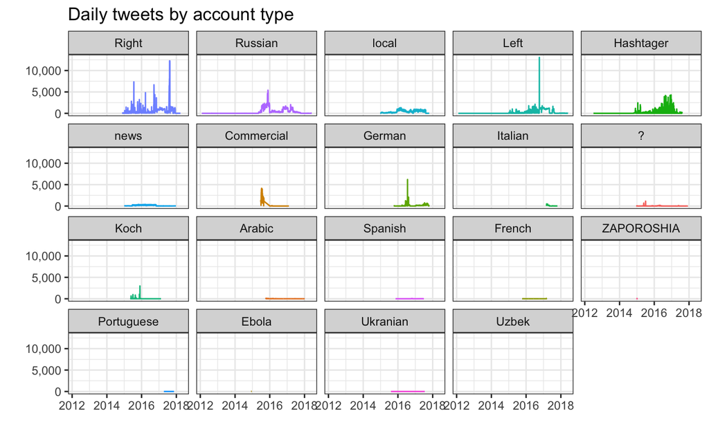

Count tweets by hour of publication.

Plot `hour_counts`.

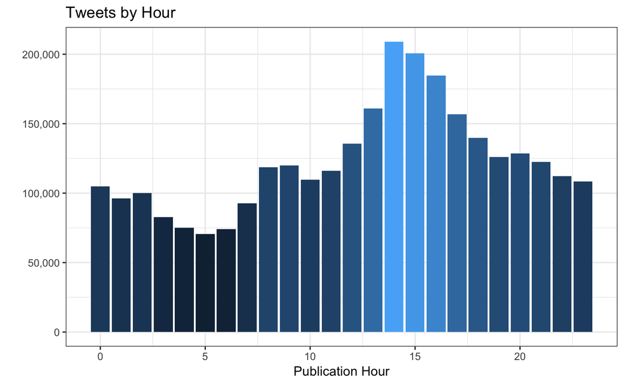

Check how many different `account_type` values there are and how many of each level are represented.

| account_type | n |
| --- | --- |
| ? | 13539 |
| Arabic | 6228 |
| Commercial | 121904 |
| Ebola | 71 |
| French | 1117 |
| German | 91511 |
| Hashtager | 241786 |
| Italian | 15680 |
| Koch | 10894 |
| Left | 427141 |

[output cut: 9 more lines]

Create condensed account_type groups.

Count the newly condensed groups.

| account_type_c | n |
| --- | --- |
| Left | 427141 |
| local | 459220 |
| Right | 711668 |
| Russian | 704917 |
| Other | 643261 |

Count tweets by date and new `account_type` groups.

Plot new `date_counts`.

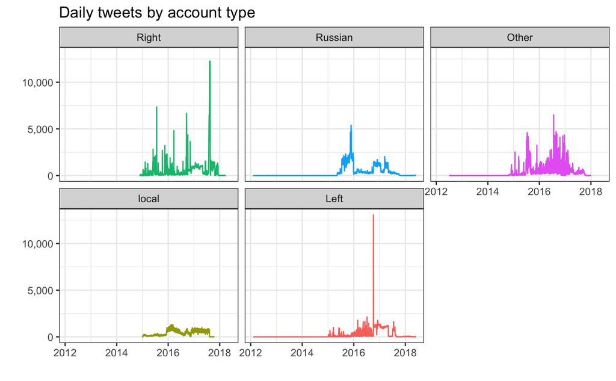

## Tidytext

[`tidytext`](https://github.com/juliasilge/tidytext) is an R package for text analysis. Grab a sample of `tweets`

```r
set.seed(35487)
tweets_s <- tweets %>%
  # Remove non-English
  filter(language == "English") %>%
  sample_n(50000)
```

Separate out tokens in tweets. In other words, create each word of `content` as it’s own row.

```r
tweets_s_tokens <- tweets_s %>%
  select(external_author_id, content, account_type_c, publish_date_d) %>%
  unnest_tokens(output = words, input = content)
```

Remove stop words (common words)

```r
tweets_s_tokens <- tweets_s_tokens %>%
  anti_join(get_stopwords(), by = c("words" = "word")) %>%
  filter(!words %in% c("t.co", "http", "https"))
```

Count most common words by `account_type`.

```r
word_counts <- tweets_s_tokens %>%
  count(words, account_type_c, sort = TRUE)
```

Plot most common words by `account_type`

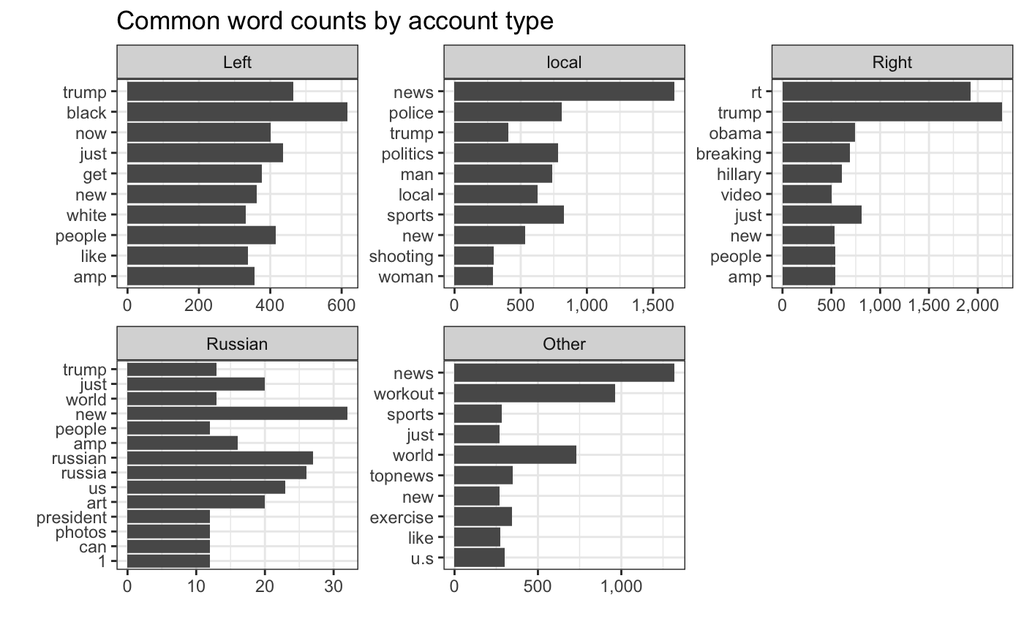